# Are shots predictive of soccer results?

A Stan model for the shoting soccer ability

L. Egidi, F. Pauli, N. Torelli - University of Trieste, Italy

StanCon Helsinki, 29-31 August 2018

# Modeling the outcome of a football match

Modeling the outcome of a football match is the subject of much debate involving different alternative models for the **number of goals** scored between two competing teams:

- Joint bivariate Poisson distribution accounting for a (positive) correlation between them (Karlis and Ntzoufras 2003);
- Two independent Poisson distributions (Baio and Blangiardo 2010; Maher 1982; Rue and Salvesen 2000);
- Negative binomial models;
- Models for the goal difference, where the likelihood is a $t$ distribution (Gelman World Cup model) or a Skellam distribution (Karlis and Ntzoufras 2009).

# Beyond the scores information

These models allow for estimating **attack** and **defense** team abilities *only* using the past results.

However, these abilities are strongly correlated with other game features, such as the shots and the shots conceded respectively.

We enrich the existing framework by proposing a Bayesian hierarchical model consisting of a data-hierarchy in three stages for each game and each team, modeling the following nested quantities: **number of scores**, **number of shots on target** and **number of total shots**.

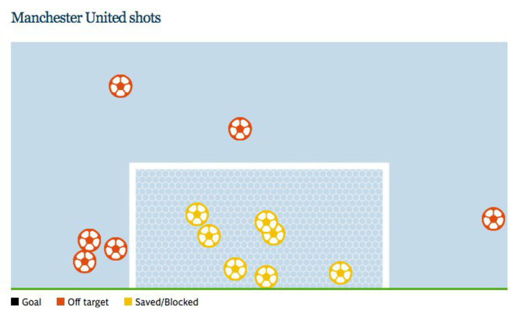

# Why do we need a shots model?

- Shots data are likely to be influential for football, *but* they are registered only for the past matches. Of course, we do not know in advance the number of shots (both for the home and the away team) for the match that will be played tomorrow…
- Then, we need a **model**, and we cannot include shots as covariates in a simple model for the scores.
- As far as we know from reviewing the literature, there are no attempts for incorporating the shots within a model for the scores.
- Comparing a shots model with a simple Poisson model not accounting for shots information could be useful.

# Data

- Nine seasons for the English Premier League (EPL)
- Eight seasons (from 2008/2009 to 2015/2016), 3040 matches, train set
- The nineth season, 2016/2017, 380 matches, is our test set, used for prediction purposes
- $T=34$ teams
- We fit the model in $\mathsf{Stan}$ and we analyze the output using $\mathsf{R}$.
- Data publicy available from https://football-data.co.uk.

# Data: notation

For each match $n$, the data information is represented by the joint vector $(\mathbf{y}, \mathbf{s}, \mathbf{w})$:

- $\mathbf{y}_n=(y_{n1}, y_{n2})$ : vector of observed scores, where $y_{n1}$ and $y_{n2}$ are the number of goals scored by the home team and by the away team in the $n$-th match of the dataset, respectively
- $\mathbf{s}_n=(s_{n1}, s_{n2})$: shots on the target
- $\mathbf{w}_{n}=(w_{n1}, w_{n2})$: total number of shots
- The nested indexes $h(n), a(n)=1,\ldots, T$ and $\tau(n)$ identify the home team, the away team and the season $\tau$ associated with the $n$-th game, respectively.

# Stan code: data

```r
data {
  int N;                            // number of matches
  int nseason;                      // number of seasons
  int season[N];                    // season index
  int score_home[N];                // home scores
  int score_away[N];                // away scores
  int Shots_home[N];                // home shots on target
  int Shots_away[N];                // away total shots on target
  int Tot_Shots_home[N];            // home total shots
  int Tot_Shots_away[N];            // away total shots
  int nteams;                       // number of teams
  int teams_home[N];                // team home index
  int teams_away[N];                // team away index
  int N_prev;                       // number of predicted matches
  int teams_home_prev[N_prev];      // team home predicted index
  int teams_away_prev[N_prev];      // team away predicted index
  int season_prev[N_prev];          // season predicted index
  int season_time[nseason];
}
```

# Model: data

For $n=1,\ldots,N$:

$$\begin{align}
\begin{split}
y_{n1}& \sim \mathsf{Binomial}(s_{n1}, p_{h(n),\ \tau(n)}) \\
y_{n2}& \sim \mathsf{Binomial}(s_{n2}, q_{a(n),\ \tau(n)}) \\
s_{n1} & \sim \mathsf{Binomial}(w_{n1}, u_{h(n)})\\
s_{n2} & \sim \mathsf{Binomial}(w_{n2}, v_{a(n)})\\
w_{nj}| \theta_{nj} &\sim \mathsf{NegBinomial}(\theta_{nj}, \phi), \ \ j=1,2,\\
%s_{m1} & \perp s_{m2} | \theta_{m1}, \theta_{m2}.
\end{split}
\label{eq:model}
\end{align}$$

where:

- $p$ and $q$ are the conversion probabilities, expressing the probability of converting a shot on target in a goal for an home and an away team, respectively;
- $u$ and $v$ are the shots precision probabilities, expressing the probability of shoting in target for an home and an away team, respectively;
- $\theta_{n1}$ and $\theta_{n2}$ are the shoting rates.

# Model: conversion probabilities

*Conversion probabilities* $p$ and $q$:

$$\begin{align}
\begin{split}
p_{h(n),\ \tau(n)} & = \mbox{logit}^{-1}(\mu+att_{h(n),\ \tau(n)}+def_{a(n) ,\ \tau(n)})\\
q_{a(n),\ \tau(n)} & = \mbox{logit}^{-1}(att_{a(n),\ \tau(n)}+def_{h(n),\ \tau(n) }).
\end{split}
\label{eq:conv_prob}
\end{align}$$

The attack and defence parameters for a generic team are assumed to to be dynamic (Owen 2011) and follow two Gaussian processes:

$$\begin{align}
\begin{split}
att_{\cdot,\tau} \sim & \mathsf{GP}(\mu_{att}(\tau), k(\tau)),\\
def_{\cdot, \tau} \sim & \mathsf{GP}(\mu_{def}(\tau), k(\tau)),
\end{split}
\label{eq:att_def}
\end{align}$$

with mean functions $\mu_{att}( \tau)=0,\ \mu_{def}(\tau)=0$, and covariance function with generic element $k(\tau)_{i,j}= \exp \{ -(\tau_{i}-\tau_{j})^{2} \}+0.1$.

As outlined in the literature, a `zero-sum’ identifiability constraint within each season is required, for $T$ teams we assume: $\sum_{t=1}^{T} att_{t ,\tau}=0,\ \sum_{t=1}^{T}def_{t,\tau}=0, \tau=1,\ldots \mathcal{T}$.

# Model: precision probabilities and shoting rates

*Shots’ precision probabilities* $u$ and $v$ and *shoting rates* $\theta_{n1}, \theta_{n2}$:

$$\begin{align}
u_{h(n)} &\sim \mathsf{Beta}(\delta_{h(n)},\epsilon_{h(n)}), \ v_{a(n)} \sim \mathsf{Beta}(\delta_{a(n)},\epsilon_{a(n)}) \\
\theta_{n1} &\sim \mathsf{Gamma}(\alpha_{h(n)},\beta_{h(n)}), \ \theta_{n2} \sim \mathsf{Gamma}(\alpha_{a(n)},\beta_{a(n)}).
\end{align}$$

Weakly informative priors for the home effect parameter $\mu$, the overdispersion parameter $\phi$, and the hyperparameters $\alpha,\beta,\delta,\epsilon$ are assigned:

$$\begin{align}
\phi \sim \mathsf{Normal}(0,1)\\
\alpha \sim \mathsf{Normal}(0,5)\\
\beta \sim \mathsf{Normal}(0,5)\\
\delta \sim \mathsf{Normal}(0,5)\\
\epsilon \sim \mathsf{Normal}(0,5)
\end{align}$$

# Stan code: parameters

```r
 parameters {
  real mu;                          // home effect parameter
  real<lower=0> phi;                // overdispersion total shots
  vector<lower=0>[nteams] alpha;    // total shots shape
  vector<lower=0>[nteams] beta;     // total shots rate
  vector<lower=0>[nteams] delta;    // beta shape 1
  vector<lower=0>[nteams] epsilon;  // beta shape 2
  matrix[nseason, nteams] att_raw;  // raw attack ability
  matrix[nseason, nteams] def_raw;  // raw defense ability
  vector<lower=0>[N] theta_home;    // home total shots rate
  vector<lower=0>[N] theta_away;    // away total shots rate
 }
```

# Stan code: transformed parameters

```r
 transformed parameters{
  matrix[nseason, nteams] att;        // attack abilities
  matrix[nseason, nteams] def;        // defense abilities
  cov_matrix[nseason] Sigma_att;      // GP attack cov. funct.
  cov_matrix[nseason] Sigma_def;      // GP defense cov.funct.
  matrix[nseason, nteams] mu_att;     // attack hyperparameter
  matrix[nseason, nteams] mu_def;     // defense hyperparameter
  matrix<lower=0, upper=1>[nteams,nseason-1] p;  // conversion home p
  matrix<lower=0, upper=1>[nteams,nseason-1] q;  // conversion away q

  p = rep_matrix(0.2, nteams, nseason-1);
  q = rep_matrix(0.2, nteams, nseason-1);


  // Gaussian process covariance functions
   for (i in 1:(nseason)){
     for (j in 1:(nseason)){
       Sigma_att[i, j] = exp(-pow(season_time[i] - season_time[j], 2))
       + (i == j ? 0.1 : 0.0);
       Sigma_def[i, j] = exp(-pow(season_time[i] - season_time[j], 2))
                   + (i == j ? 0.1 : 0.0);
     }}

  // Sum-to-zero constraint for attack/defense parameters
  att[1] = att_raw[1]-mean(att_raw[1]);
  def[1] = def_raw[1]-mean(def_raw[1]);
   for (t in 2:nseason){
      att[t] = att_raw[t]-mean(att_raw[t]);
      def[t] = def_raw[t]-mean(def_raw[t]);
     }

  // Lagged prior mean for attack/defense parameters
   for (t in 2:nseason){
     mu_att[1] = rep_row_vector(0,nteams);
     mu_att[t] = rep_row_vector(0,nteams);
     mu_def[1] = rep_row_vector(0,nteams);
     mu_def[t] = rep_row_vector(0,nteams);
     }

  // Conversion probabilities
   for (n in 1:N){
     p[teams_home[n], season[n]] = inv_logit(mu+att[season[n], teams_home[n]]
                                    +def[season[n], teams_away[n]]);
     q[teams_away[n], season[n]] = inv_logit(att[season[n], teams_away[n]]
                                    +def[season[n], teams_home[n]]);
     }
 }
```

# Stan code: model

```r
 model{
  // Priors
  target+=normal_lpdf(phi|0,1);
  target+=normal_lpdf(alpha |0,5);
  target+=normal_lpdf(beta |0,5);
  target+=normal_lpdf(delta |0,5);
  target+=normal_lpdf(epsilon |0,5);

   for (h in 1:(nteams)){
     att_raw[,h] ~ multi_normal(mu_att[,h], Sigma_att);
     def_raw[,h] ~ multi_normal(mu_def[,h], Sigma_def);
   }

  // Likelihood
   for (n in 1:N){
     target+= binomial_lpmf(score_home[n] |  Shots_home[n],
                            p[teams_home[n],season[n]]);
     target+= binomial_lpmf(score_away[n] |  Shots_away[n],
                            q[teams_away[n], season[n]]);
     target+= beta_binomial_lpmf(Shots_home[n] |  Tot_Shots_home[n],
                                 delta[teams_home[n]],epsilon[teams_home[n]]);
     target+= beta_binomial_lpmf(Shots_away[n] |  Tot_Shots_away[n],
                                 delta[teams_away[n]],epsilon[teams_away[n]]);
     target+=gamma_lpdf(theta_home[n]|alpha[teams_home[n]],beta[teams_home[n]]);
     target+=gamma_lpdf(theta_away[n]|alpha[teams_away[n]],beta[teams_away[n]]);
      }

  target+= neg_binomial_2_lpmf(Tot_Shots_home|theta_home, phi );
  target+= neg_binomial_2_lpmf(Tot_Shots_away|theta_away, phi);
 }
```

# Fitting the model

4 chains, 2000 HMC iterations each.

```r
# data
shots_data <- list(N=ngames_train, N_prev=ngames_test, score_home=score1,
                   score_away=score2, Shots_home=kicks1_target,
                   Shots_away=kicks2_target, Tot_Shots_home=kicks1,
                   Tot_Shots_away=kicks2, nteams=nteams,
                   teams_home=team1, teams_away=team2,
                   teams_home_prev=team1_prev, teams_away_prev=team2_prev,
                   season=season_or, season_prev=season_prev, nseason=nseason,
                   season_time=season_time)

# fit stan model
mod_shots_stan <- stan(file="shots.stan", data=shots_data,  iter = 2000,
                       chains = 4, cores = 4, seed = 1)

#  extract posterior output
sims <- extract(mod_shots_stan)
```

# Parameters estimates

For all the parameters the Gelman-Rubin statistic $\hat{R}< 1.1$. We report here:

- 50% posterior intervals across the differents seasons for the parameters $att$ (orange solid lines) and $def$ (black solid lines). Higher values for the attack: greater propensity to convert the shots on target in goals. Lower values for the defense correspond to a better ability to not concede goals.
- 50% posterior intervals for the conversion home probabilities $p_{t, \tau}$ (solid red line) and the conversion away probabilities $q_{t,\tau}$ (solid blue line) for team $t=1,\ldots, T$ across the different seasons $\tau=1\,\ldots,\mathcal{T}$. Red points and blue points denote the observed conversion rates for the nine teams always belonging to the EPL during the eight train set seasons.
- Average shoting rates, $\bar{\theta}_1, \bar{\theta}_2$ for home teams (red bars) and away teams (blue bars) respectively.

# Evolution of team abilities across the seasons

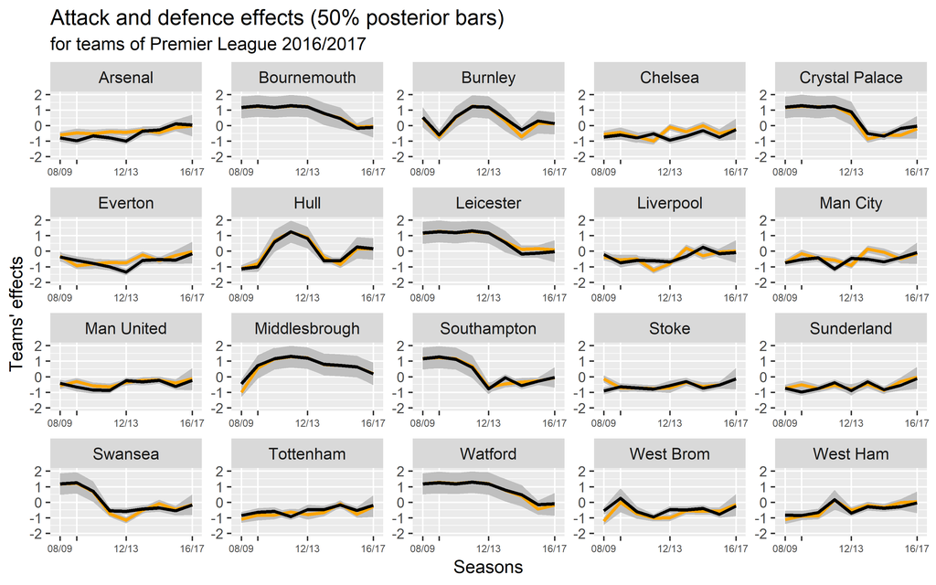

# Evolution of conversion probabilities

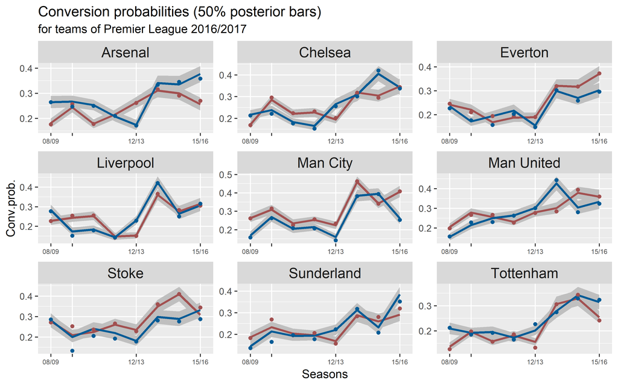

# Average shoting rates

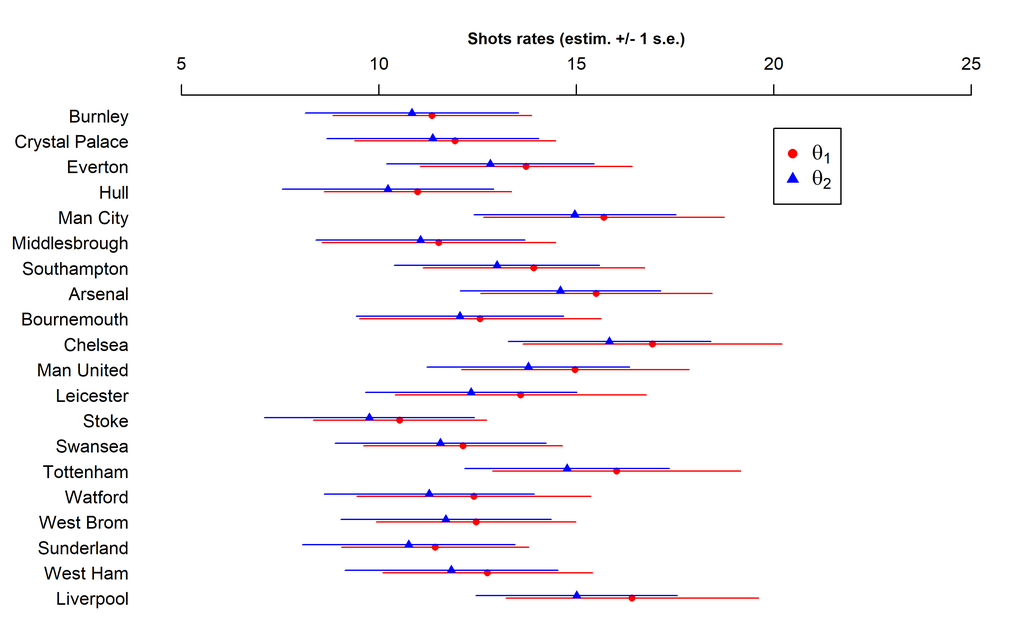

# Model checking

We used the data replicated in the `generated quantities` block for assessing the global goodness of fit of the proposed model. Thus, we draw simulated values $y^{rep}$ from the joint predictive distribution of replicated data:

$$\begin{equation*}
p(y^{rep}|y) = \int_{\Theta} p({y}^{rep}, \theta|y) d\theta= \int_{\Theta} p(\theta|y)p({y}^{rep}|\theta) d\theta.
\label{posterior_predicitve_1}
\end{equation*}$$

Next figure shows the posterior medians (red crosses), the posterior 95% intervals (lightyellow) and 50% posterior (dark yellow) against the observed score difference $y_{n1}-y_{n2}$.

- 95.1% of the observed score differences fall inside the 95% uncertainty intervals;
- 40% of the observed differences fall inside the 50% uncertainty intervals.

# Model checking

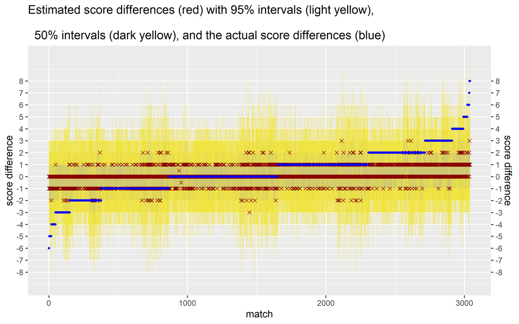

# Stan code: generated quantities

```r
 generated quantities{
  vector[N] log_lik;            // pointwise log-likelihood
  int score_home_rep[N];        // in-sample home scores
  int score_away_rep[N];        // in-sample away scores
  int Shots_home_rep[N];        // in-sample home shots on t.
  int Shots_away_rep[N];        // in-sample away shots on t.
  int Tot_Shots_home_rep[N];    // in-sample home total shots
  int Tot_Shots_away_rep[N];    // in-sample away total shots
  int score_home_prev[N_prev];  // out-of-sample home scores
  int score_away_prev[N_prev];  // out-of-sample away scores
  int Shots_home_prev[N_prev];  // out-of-sample home shots on t.
  int Shots_away_prev[N_prev];  // out-of-sample away shots on t.
  int Tot_Shots_home_prev[N_prev];  // out-of-sample home total shots
  int Tot_Shots_away_prev[N_prev];  // out-of-sample away total shots
  vector<lower=0>[N_prev] theta_home_prev;   // predicted home shooting rate
  vector<lower=0>[N_prev] theta_away_prev;   // predicted away shooting rate
  vector<lower=0, upper=1>[nteams] p_prev;   // pred. conversion home prob.
  vector<lower=0, upper=1>[nteams] q_prev;   // pred. conversion away prob.

    for (n in 1:N){
      Tot_Shots_home_rep[n] = neg_binomial_2_rng(theta_home[n], phi);
      Tot_Shots_away_rep[n] = neg_binomial_2_rng(theta_away[n], phi);
      Shots_home_rep[n]     = beta_binomial_rng(Tot_Shots_home_rep[n],
                               delta[teams_home[n]],epsilon[teams_home[n]]);
      Shots_away_rep[n]     = beta_binomial_rng(Tot_Shots_away_rep[n],
                               delta[teams_away[n]],epsilon[teams_away[n]]);
      score_home_rep[n]     = binomial_rng(Shots_home_rep[n],
                               p[teams_home[n], season[n]]);
      score_away_rep[n]     = binomial_rng(Shots_away_rep[n],
                               q[teams_away[n], season[n]]);
      log_lik[n]            =binomial_lpmf(score_home[n] |
                              Shots_home[n],  p[teams_home[n],season[n]])+
                             binomial_lpmf(score_away[n] |
                              Shots_away[n], q[teams_away[n],
                                season[n]]);
      }

  // p_prev initialization
   p_prev = p[,nseason-1];
   q_prev = q[,nseason-1];

    for (n in 1:N_prev){
      p_prev[teams_home_prev[n]] = p[teams_home_prev[n], nseason-1];
      q_prev[teams_away_prev[n]] = q[teams_away_prev[n], nseason-1];
      theta_home_prev[n]         = gamma_rng(alpha[teams_home_prev[n]],
                                    beta[teams_home_prev[n]]);
      theta_away_prev[n]         = gamma_rng(alpha[teams_away_prev[n]],
                                    beta[teams_away_prev[n]]);
      Tot_Shots_home_prev[n]     = neg_binomial_2_rng(theta_home_prev[n], phi);
      Tot_Shots_away_prev[n]     = neg_binomial_2_rng(theta_away_prev[n], phi);
      Shots_home_prev[n]         = beta_binomial_rng(Tot_Shots_home_prev[n],
                                    delta[teams_home_prev[n]],
                                    epsilon[teams_home_prev[n]]);
      Shots_away_prev[n]         = beta_binomial_rng(Tot_Shots_away_prev[n],
                                    delta[teams_away_prev[n]],
                                    epsilon[teams_away_prev[n]]);
      score_home_prev[n]         = binomial_rng(Shots_home_prev[n],
                                    p_prev[teams_home_prev[n]]);
      score_away_prev[n]         = binomial_rng(Shots_away_prev[n],
                                    q_prev[teams_away_prev[n]]);
        }
}
```

# Compute the LOOIC

We compared the LOOIC under our model with the LOOIC for a simple double Poisson model, the default choice for modeling the football results (here only the EPL season 2016-2017 is used).

```r
mod_shots_stan <- stan(file="shots_sis.stan", data=shots_data,  iter = 2000,
                       chains = 4, cores = 4, seed = 1)

double_poi_stan <- stan(file="double_poisson.stan", data=scores_data,
                        iter = 2000, chains = 4, cores = 4, seed = 1)

log_lik1 <- extract_log_lik(mod_shots_stan)
loo1 <- loo(log_lik1)

log_lik2 <- extract_log_lik(double_poi_stan)
loo2 <- loo(log_lik2)
```

|  | LOOIC | LOOIC_SE |
| --- | --- | --- |
| Double Poisson | 1133.8 | 25.1 |
| Shots model | 1132.3 | 30.0 |

# Posterior prediction probabilities

Making predictions is the hottest part for a sport statistician. We may predict:

- single match results;
- the final number of rank points;
- the relegated teams;
- etc.

All we need are **posterior probabilities** for future matches, obtained through HMC samples for future values $\tilde{y}_{m1}, \tilde{y}_{m2}$, denoted with `score_home_prev` and `score_away_prev` respectively, and saved in the `sims` objects. We denote with $\tilde{y}$ a generic unknown observable. Its distribution is then conditional on the observed $y$,

$$\begin{equation*}
p(\tilde{y}|y) = \int_{\Theta} p(\tilde{y}, \theta|y) d\theta= \int_{\Theta} p(\theta|y)p(\tilde{y}|\theta) d\theta,
\label{posterior_predicitve_2}
\end{equation*}$$

where the conditional independence of $y$ and $\tilde{y}$ given $\theta$ is assumed.

# Joint posterior distribution of the results

Next figure shows the joint posterior probabiities for the goals in one of the future matches, between Middlesbrough (home team) and Stoke City (away team): darker region are associated with more likely results. The red square corresponds to the observed result.

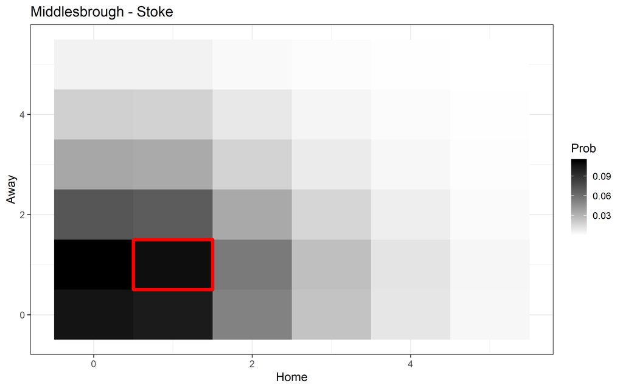

# Model check predictions

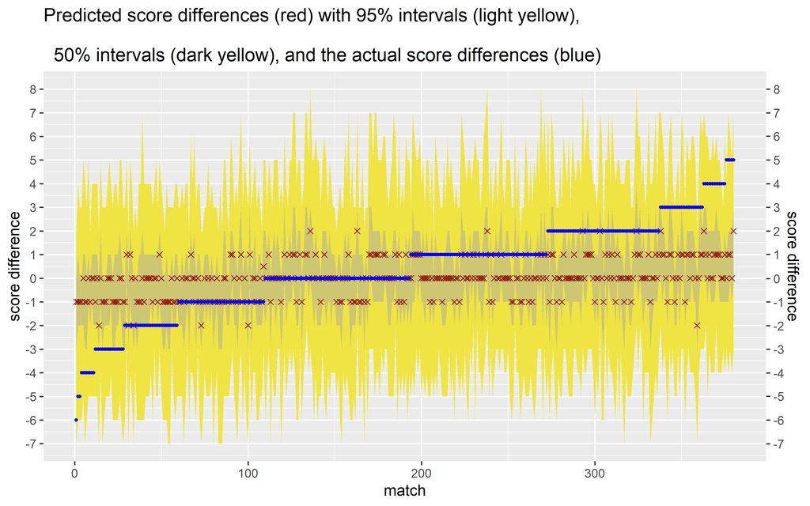

# Final EPL 2016/2017 rank

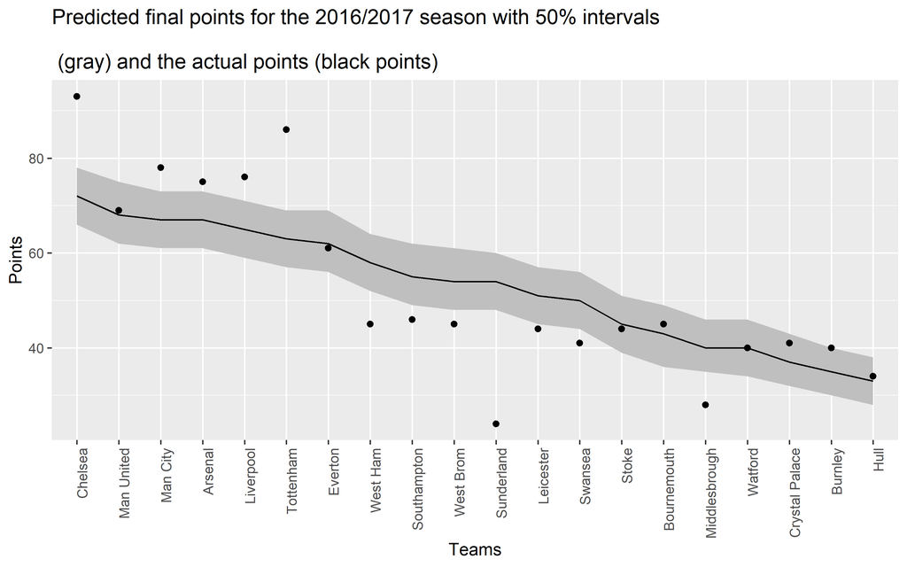

The model is able to predict Chelsea as EPL champion at the end of the 2016/2017 season. It clearly detects the best EPL teams: Manchester United, Arsenal, Liverpool and Manchester City.

# Posterior probabilities for exact rank positions

- First three positions

| Team | Prob(1st) | Prob(2nd) | Prob(3rd) | Actual rank | Observed points |
| --- | --- | --- | --- | --- | --- |
| Chelsea | 0.29 | 0.18 | 0.14 | 1 | 93 |
| Tottenham | 0.06 | 0.07 | 0.1 | 2 | 86 |
| Man City | 0.12 | 0.13 | 0.13 | 3 | 78 |

- Relegated teams

| Team | Prob(1rel) | Prob(2rel) | Prob(3rel) | Actual rank | Observed points |
| --- | --- | --- | --- | --- | --- |
| Hull | 0.16 | 0.22 | 0.27 | 18 | 34 |
| Middlesbrough | 0.13 | 0.1 | 0.07 | 19 | 28 |
| Sunderland | 0.02 | 0.01 | 0.00225 | 20 | 24 |

# Predictive accuracy

We may compute the *Brier score*, a proper score function that measures the accuracy of probabilistic predictions, the mean squared error of the forecast:
$$\bar{b}=\frac{1}{N} \sum_{n=1}^{N}\sum_{i=1}^{3}(p_{i,n}-\delta_{i,n})^2,$$
where $p_{i,n}$ is the model probability for the $i$-th outcome, $i \in \{\text{Win}, \text{Draw}, \text{Loss} \}$ in the $n$-th game, and $\delta_{i,n}$ the Kroenecker delta. The Brier score is bounded between 0 and 2, and the lower is this index the better is the prediction accuracy.

```r
# compute the brier score

brier_score_shots <- (1/ngames_test)*sum( (shots_prob-results_brier)^2)
brier_score_pois  <- (1/ngames_test)*sum( (double_poi_prob-results_brier)^2)
```

|  | Brier score |
| --- | --- |
| Double Poisson | 0.62 |
| Shots model | 0.59 |

# A naive betting strategy

We may use the posterior means for the distribution of the score difference, $\tilde{y}_{n1}-\tilde{y}_{n2}$, and we bet on an home win (draw, away win) if the rounded posterior mean for the $n$-th score difference is greater than (equal, less than) zero. The result is displayed in the plot below. The final cumulative amount of money is greater than the initial amount, although the winning rate is only the 1.3%

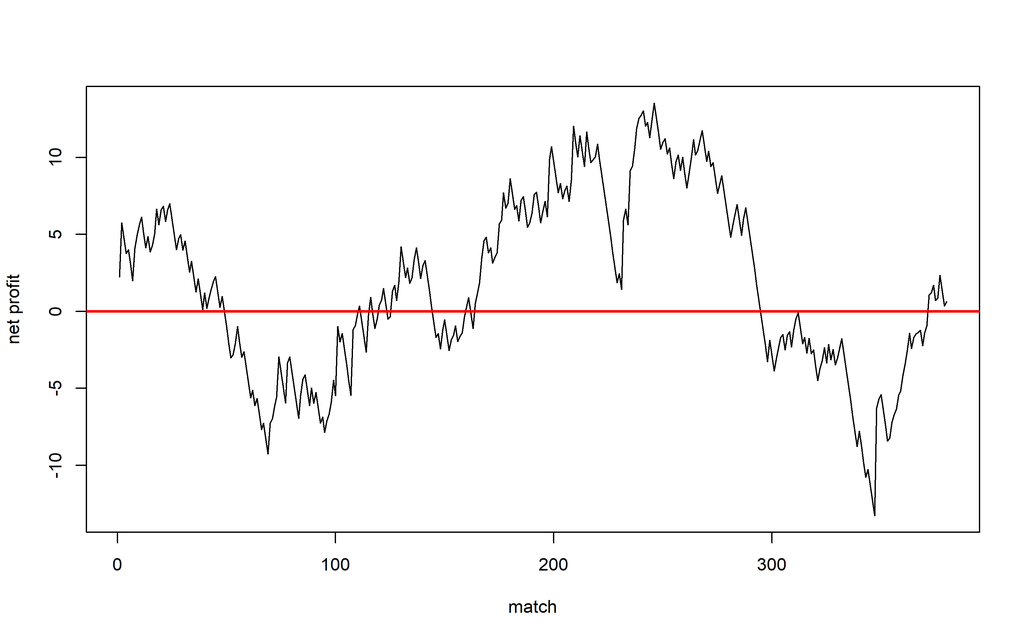

# Conclusions

Including the shots in a scoring model:

- enriches the existing framework
- slightly improves over the fit
- yields better predictions.

Further work:

- correlation between scores/shots
- connect the shots model with *bookmakers* information, as partially done in Egidi, Pauli, and Torelli (2018).

Further R Code and analysis soon available at [www.leonardoegidi.com](https://www.leonardoegidi.com/) or contact me at legidi@units.it.

# References

Baio, Gianluca, and Marta Blangiardo. 2010. “Bayesian Hierarchical Model for the Prediction of Football Results.” *Journal of Applied Statistics* 37 (2). Taylor & Francis: 253–64.

Egidi, Leonardo, Francesco Pauli, and Nicola Torelli. 2018. “Combining Historical Data and Bookmakers’ Odds in Modelling Football Scores.” *arXiv Preprint arXiv:1802.08848*.

Karlis, Dimitris, and Ioannis Ntzoufras. 2003. “Analysis of Sports Data by Using Bivariate Poisson Models.” *Journal of the Royal Statistical Society: Series D (the Statistician)* 52 (3). Wiley Online Library: 381–93.

———. 2009. “Bayesian Modelling of Football Outcomes: Using the Skellam’s Distribution for the Goal Difference.” *IMA Journal of Management Mathematics* 20 (2). IMA: 133–45.

Maher, Michael J. 1982. “Modelling Association Football Scores.” *Statistica Neerlandica* 36 (3). Wiley Online Library: 109–18.

Owen, Alun. 2011. “Dynamic Bayesian Forecasting Models of Football Match Outcomes with Estimation of the Evolution Variance Parameter.” *IMA Journal of Management Mathematics* 22 (2). Oxford University Press: 99–113.

Rue, Havard, and Oyvind Salvesen. 2000. “Prediction and Retrospective Analysis of Soccer Matches in a League.” *Journal of the Royal Statistical Society: Series D (the Statistician)* 49 (3). Wiley Online Library: 399–418.